# Camera Timeframes

## Time cameras are operating

The next ingredient in the density calculation is accounting for the total time that the camera deployments are operating. For many cameras, the total operating time is simply the time from just after the initial set-up to just before the final collection. However, some cameras fail before they are picked up, most often because they run out of memory or battery power after taking many pictures of cows, vegetation or occasionally perching birds. Other cameras fail because they fall over or are knocked over by cows. We use specific criteria for determining when a camera is too displaced to use – if the 5m pole is no longer in the image field, or the camera is tilted >30° from horizontal. Some of those may be re-established either during a mid-season visit or simply when the camera tilts back (e.g. if it is on a post that cows lean on), leading to a gap in operating time for the camera.

### Deployment durations

The following plots illustrate the patterns of camera placement and take-down (or failure) over the course of each field season.

#### 2015

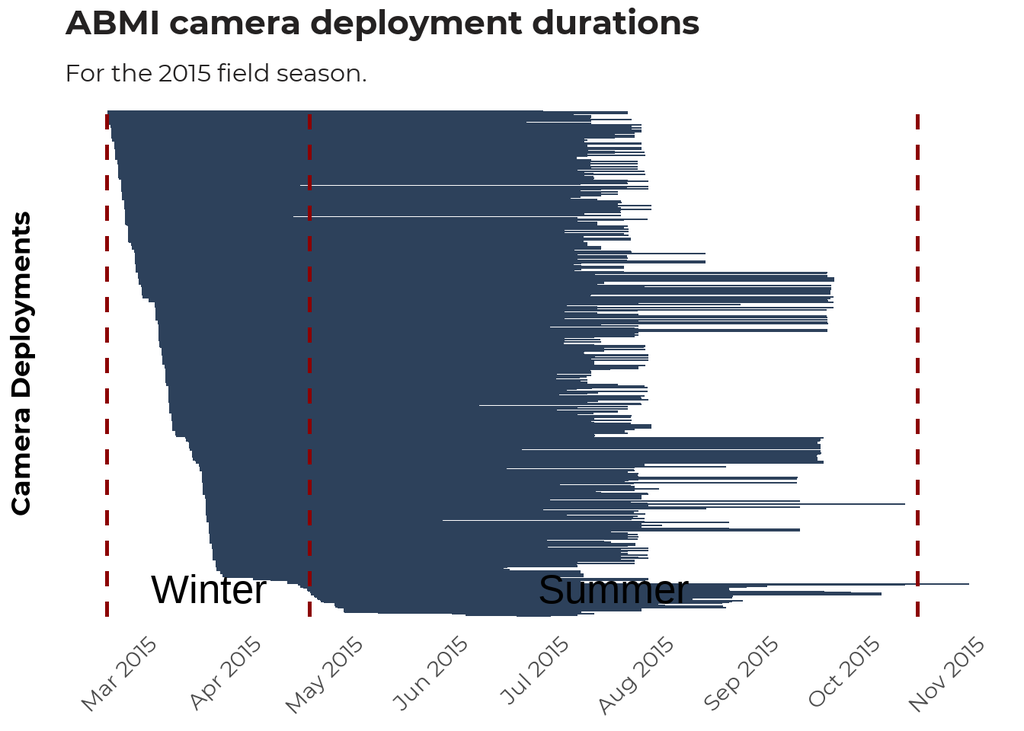

#### 2016

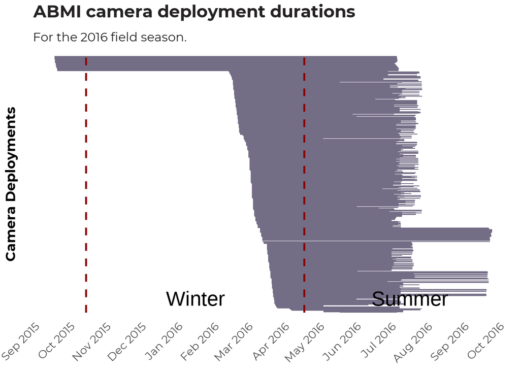

#### 2017

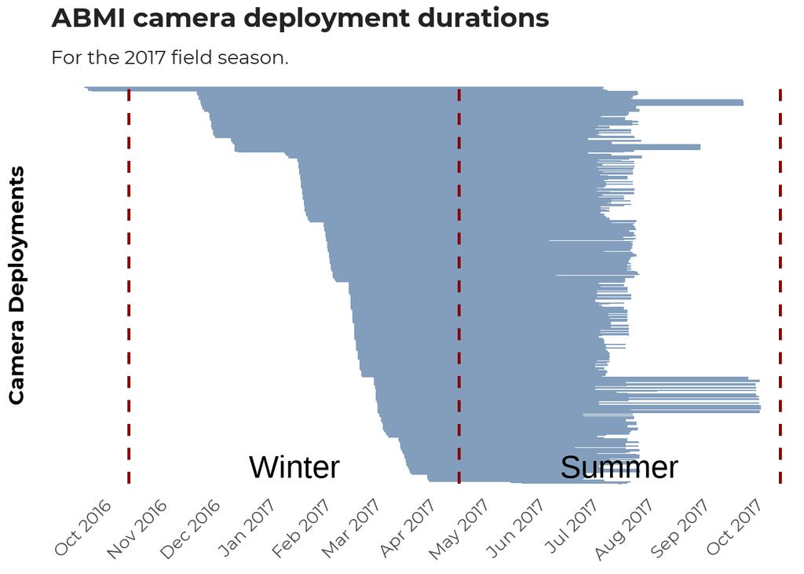

#### 2018

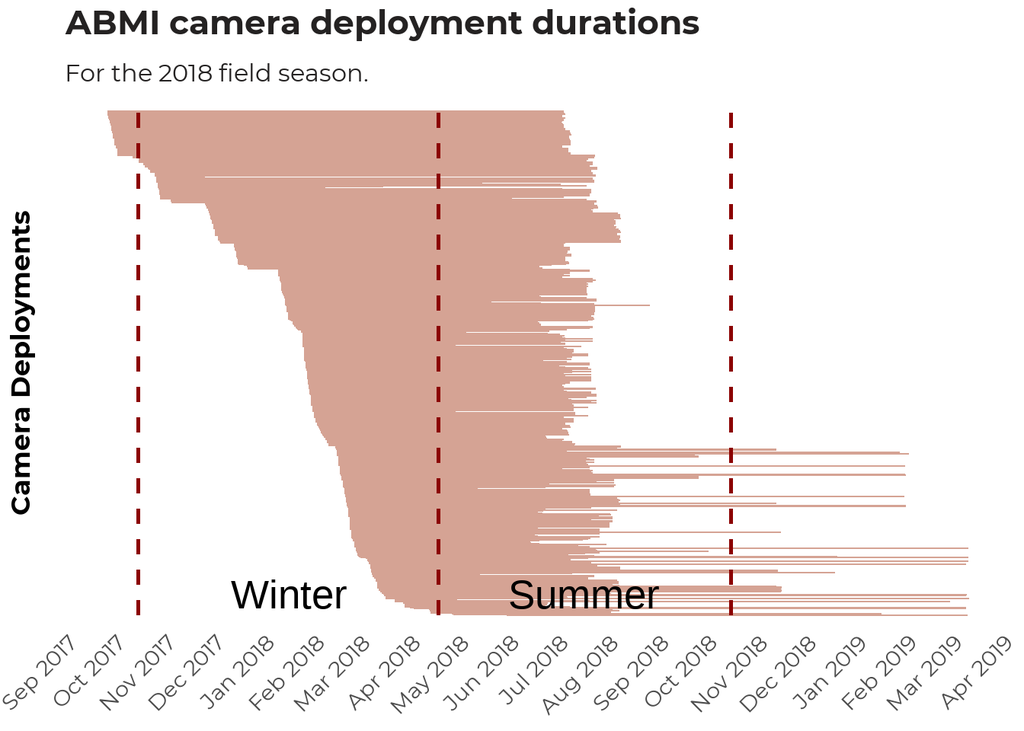

#### 2019

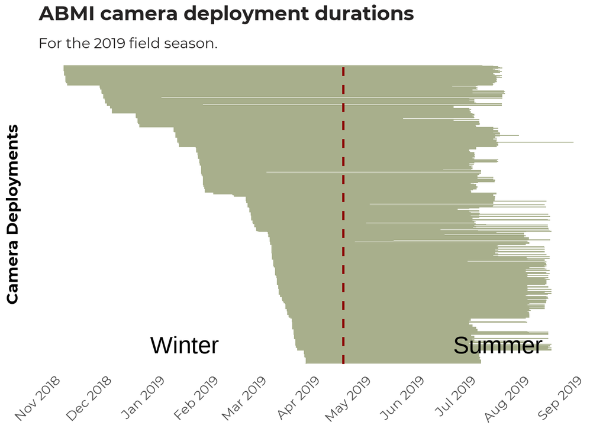

### Total deployments over time

These plots show the total number of cameras operating at each point in time over the course of a sampling season.

#### 2015

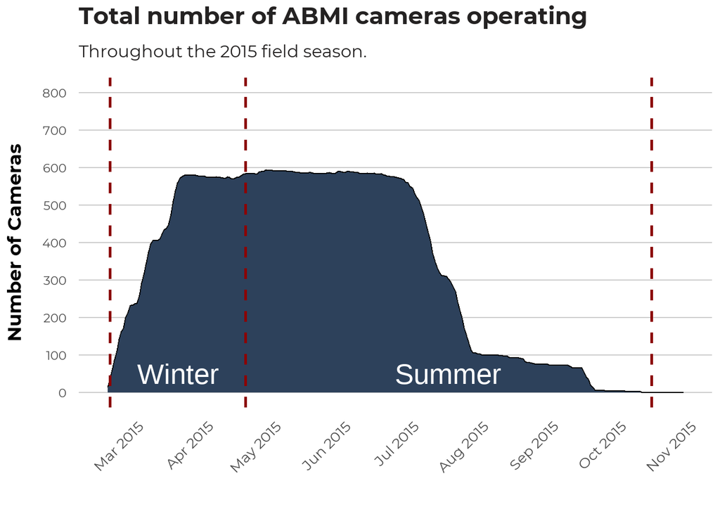

#### 2016

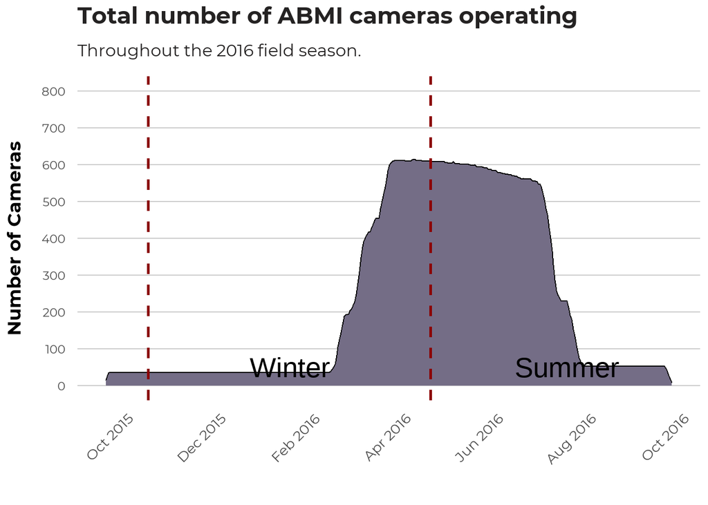

#### 2017

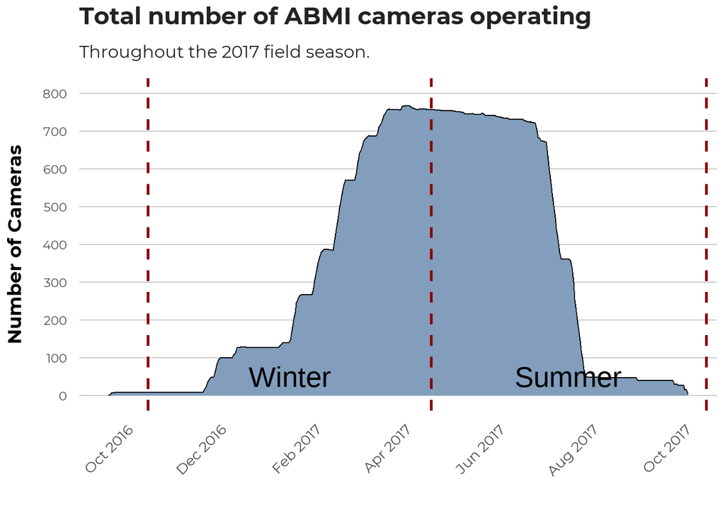

#### 2018

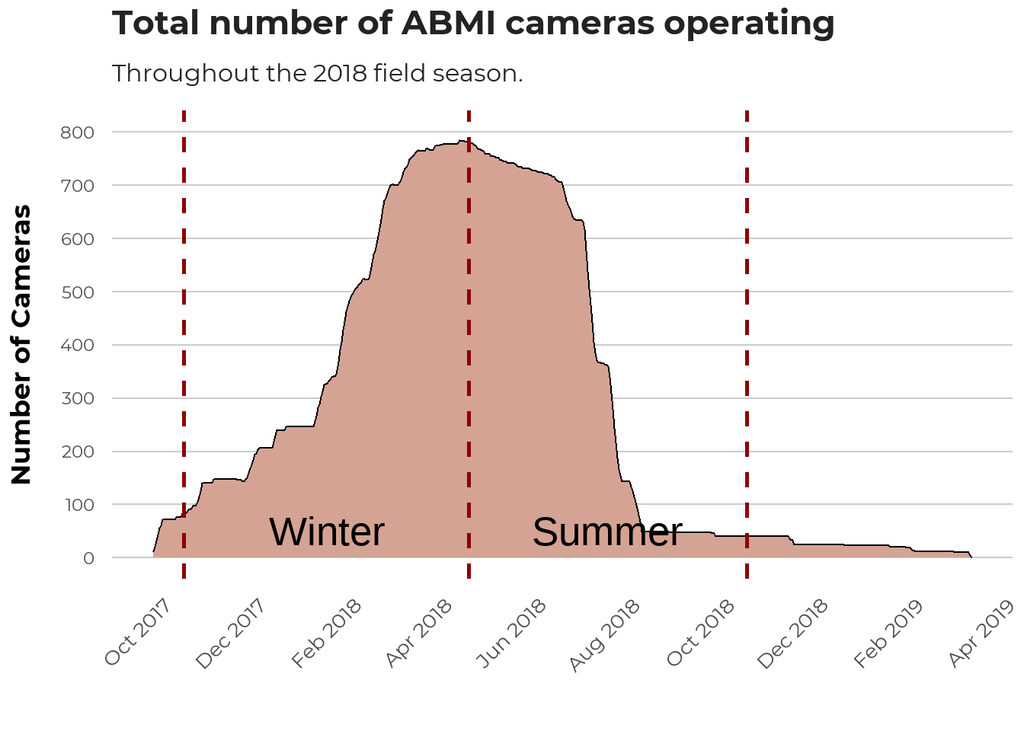

#### 2019

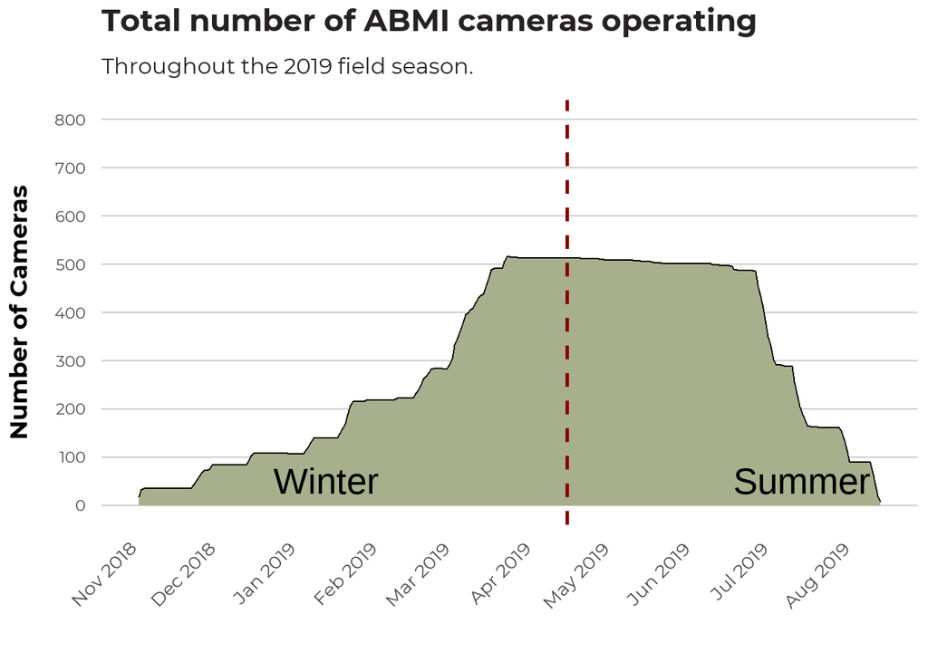

### Distribution of duration lengths

Finally, the plots below show the distribution in the number of days that the cameras were operating for each of the field seasons.

#### 2015

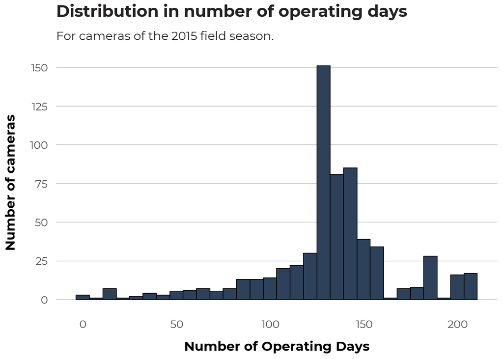

#### 2016

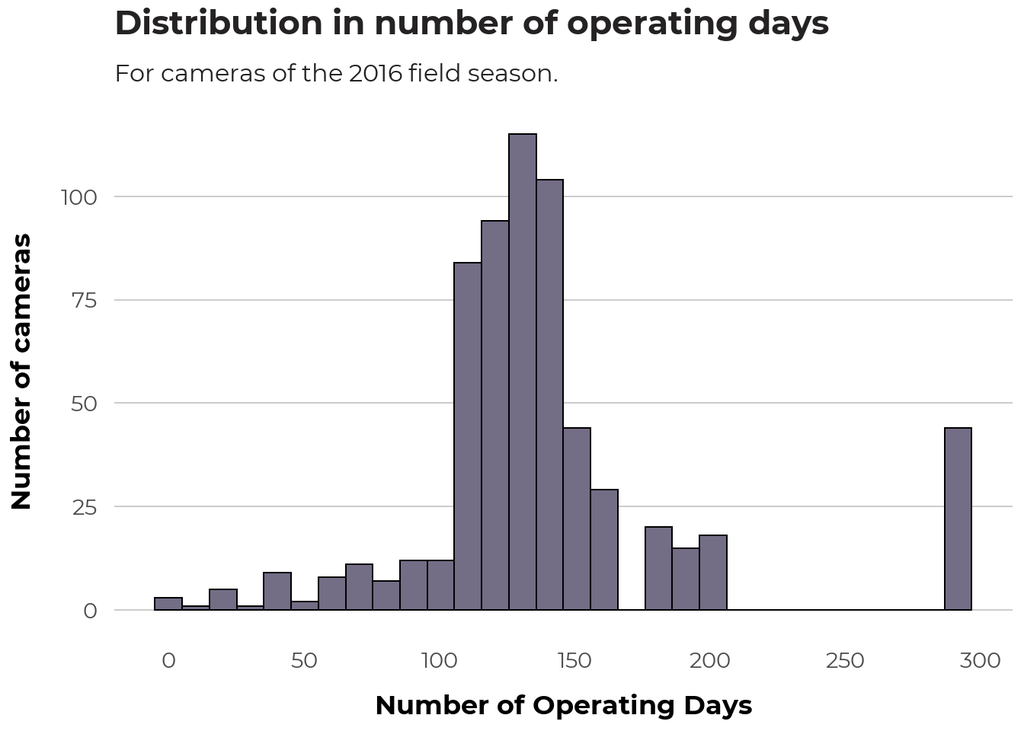

#### 2017

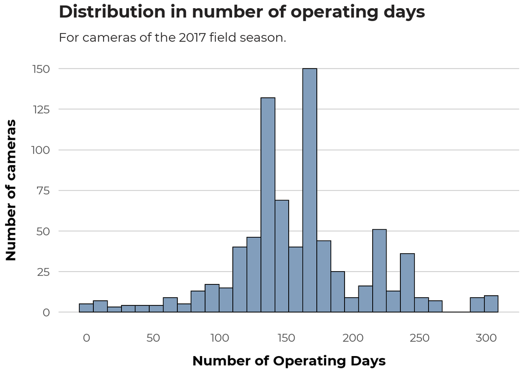

#### 2018

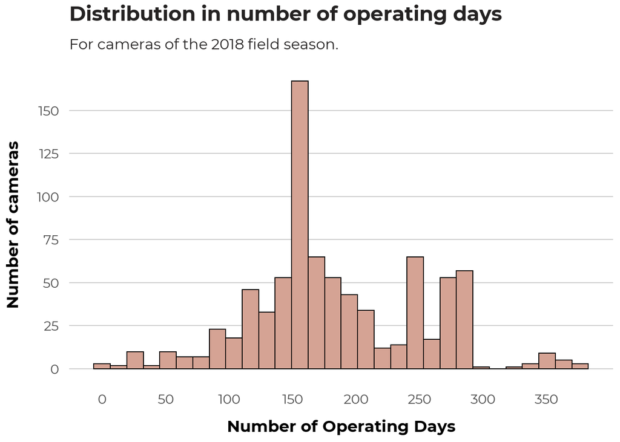

#### 2019

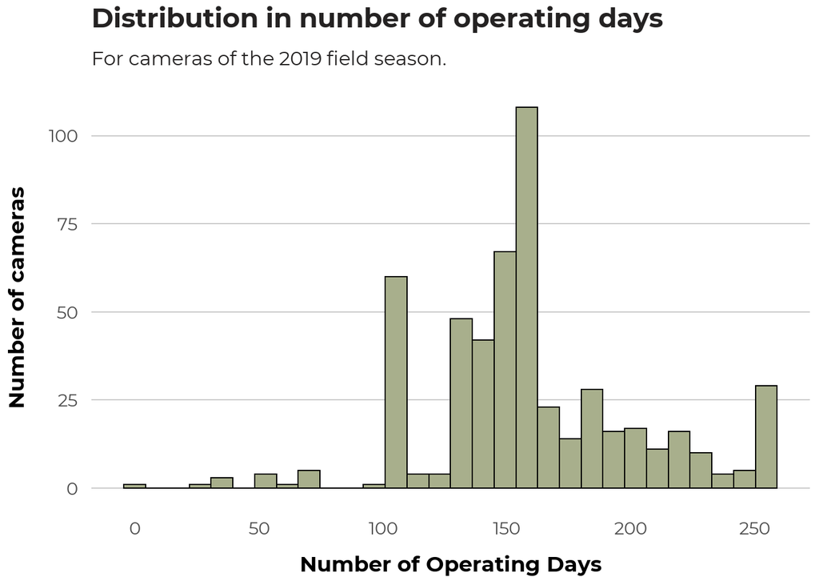

Next: [Time in field of view](https://mabecker89.github.io/abmi.camera.extras/articles/fov.html)  
Previous: [Probabilistic gaps](https://mabecker89.github.io/abmi.camera.extras/articles/gaps.html)